# DS7337_Class401_HW02_SGu_v12

### SMU NLP Course (DS7337) -- Homework 02 submission (05-29-2019)

### Shanqing Gu (Class 401)

#### 0. Data preparation

- 0.1 - Create a BeautifulSoup object based on the base URL

#### 1. Question 1

- 1.1 - Create a method for scoring the vocabulary size of a text
- 1.2 - Normalize the score from 0 to 1
- 1.3 - Barplot and save data to .csv file
- 1.4 - Explain in a short paragraph

#### 2. Question 2

- 2.1 - create a method for scoring the long-word vocabulary size of a text
- 2.2 - Normalize the score from 0 to 1
- 2.3 - Barplot and save data to .csv file
- 2.4 - Explain in a short paragraph

#### 3. Question 3

- 3.1 - Create a "text difficulty score" with scores from 3 methods
- 3.2 - Barplots of text difficulty scores
- 3.3 - Explain when this score is applied to same graded texts used in HW1

#### 0. Data Preparation

Back to top

In HW2, we are instructed to obtain all the texts of different categories from this link (http://www.gutenberg.org/wiki/Children%27s_Instructional_Books_(Bookshelf).

In total, there are 104 texts with titles hyperlinked their corresponding urls to download from 10 categories (Misc., Graded Readers, Poetry Readers, Readers for English Speakers Learning Other Languages, Non-English Readers, About Readers, Science and Nature, History, Geography, Uncategorized).

The first step is to create BeautifulSoup object with base url and html.parser for getting urls and ebook titles, and obtain the plain text UTF-8 url links for all the category books with wget function. In this step, the pattern shared in hyperlinks help convert to the final following format example: http://www.gutenberg.org/cache/epub/11313/pg11313.txt.

The second step is to clean the data by removing the tagged Gutenberg license and other unrelated information. This step will help analyze text data more accurately on lexical diversity, long-word vocabulary size, and text difficult score.

#### 0.1 - Creat a BeautifulSoup object based on the base URL

Back to top

```python
## import libraries used for HW2

import os
import numpy as np
import pandas as pd
import re
import requests

import urllib
import wget

import nltk
from nltk.corpus import PlaintextCorpusReader

from bs4 import BeautifulSoup
from urllib.request import urlopen

import matplotlib.pyplot as plt
%matplotlib inline

import seaborn as sns
sns.set(style="whitegrid")

from matplotlib import rcParams
rcParams.update({'figure.autolayout': True})
plt.rc('xtick', labelsize=15)
plt.rc('ytick', labelsize=15)
```

```python
## set working paths
home_dir = os.getcwd()
text_dir = "./text/"
plot_dir = "./plots/"

os.chdir(home_dir)
```

```python
## create BeautifulSoup object with base url and html.parser
base_url = 'http://www.gutenberg.org/wiki/Children%27s_Instructional_Books_(Bookshelf)'
soup = BeautifulSoup(urlopen(base_url).read(), 'html.parser')
```

```python
## Determine the base urls for 1st level ancor tags
base_url_level1_href_tags = []
base_url_level1_href_tags = ["http:" + tag.attrs['href'] for tag in soup.find_all(href=True, class_='extiw')]
```

```python
## check the number of base urls for 1st level ancor tags
len(base_url_level1_href_tags)
```

```
104
```

```python
## obtain the plain text UTF-8 url links for all the categorical books
base_url_plain_text_utf8 = []

for url in base_url_level1_href_tags:

    soup = BeautifulSoup(urlopen(url).read(), 'html.parser')
    href_tags = soup.find_all(href=True, text=u'Plain Text UTF-8')

    update_url = 'http:' + href_tags[0].attrs['href']

    title_tag = soup.find("title")
    title = title_tag.text.replace(' - Free Ebook', '')

    base_url_plain_text_utf8.append((update_url, title))
```

```python
## check the number of base urls for plain text
len(base_url_plain_text_utf8)
```

```
104
```

```python
## check updated urls
update_url =[]

for i in range (0, len(base_url_plain_text_utf8)):
    uu = base_url_plain_text_utf8[i][0]
    update_url.append(uu)

len(update_url)
```

```
104
```

```python
## check updated titles
title =[]

for i in range (0, len(base_url_plain_text_utf8)):
    t = base_url_plain_text_utf8[i][1]
    title.append(t)

len(title)
```

```
104
```

```python
## download all 104 texts to local directory and capture errors to identify special case urls

print('File downloads start:')

os.chdir(home_dir)
os.chdir(text_dir)

error_indx = []
pipe = ' | '

for ib in range(0, len(base_url_plain_text_utf8)) :

    url = update_url[ib]
    file_name = title[ib] + '.txt'

    try :
        wget.download(url, file_name)

    except urllib.error.HTTPError as e:

        print ("HTTP error({0}): {1}".format(e.errno, e.strerror))
        error_indx.append(str(ib) + pipe + pg_num[ib] + pipe + title[ib])

        try :
            fix_url = text_link[ib].replace('.txt', '-0.txt')
            fix_url = fix.replace('/pg', '/')
            fix_url = fix.replace('/cache/epub/', '/files/')
            fix_url = fix.replace('/cache/epub/', '/files/')
            print(fix_url)
            wget.download(fix_url, file_name)

        except :
            print ('attempted fix_url did not resolve error')

print('File downloads complete.')

error_indx
```

```
File downloads start:
File downloads complete.
```

```
[]
```

```python
## Remove gutenberg licence function
```

```python
## set working paths
files = ".*\.txt"
corpus_root = "./text"
corpus_clean = "./text_cleaned/"

os.chdir(home_dir)
```

```python
## remove the tagged gutenberg license information
def remove_gutenberg_license(text_raw) :

    head1 = '*** START OF THIS PROJECT GUTENBERG EBOOK'
    head2 = '*** START OF THE PROJECT GUTENBERG EBOOK'
    head3 = '***START OF THE PROJECT GUTENBERG EBOOK'

    tail1 = 'End of the Project Gutenberg EBook'
    tail2 = 'End of Project Gutenberg'
    tail3 = '***END OF THE PROJECT GUTENBERG EBOOK'

    try :
        book_tail_text = text_raw.split(head1, 1)[1]

    except IndexError:
        try :
            book_tail_text = text_raw.split(head2, 1)[1]

        except IndexError:
            book_tail_text = text_raw.split(head3, 1)[1]

    text_without_license = book_tail_text.split(tail1, 1)[0]

    if(len(text_without_license) == len(book_tail_text)) :
        text_without_license = book_tail_text.split(tail2, 1)[0]

    if(len(text_without_license) == len(book_tail_text)) :
        text_without_license = book_tail_text.split(tail3, 1)[0]

    return text_without_license
```

```python
## read in raw downloaded texts and assemble corpus for evaluation
readers = PlaintextCorpusReader(corpus_root, files)

files = readers.fileids()
files[0:15]
```

```
['A Book of Natural History by David Starr Jordan.txt',
 'A Catechism of Familiar Things; by Anonymous.txt',
 'A First Spanish Reader by Alfred Remy and Erwin W. Roessler.txt',
 'A History of the McGuffey Readers by Henry Hobart Vail.txt',
 'A Hundred Anecdotes of Animals by Percy J. Billinghurst.txt',
 'A Little Book for A Little Cook by L. P. Hubbard.txt',
 'A Manual of Pronunciation by Otis Ashmore.txt',
 'A Modern History, From the Time of Luther to the Fall of Napoleon by John Lord.txt',
 'A Primary Reader: Old-time Stories, Fairy Tales and Myths Retold by Children.txt',
 'A School History of the United States by John Bach McMaster.txt',
 'Among the Farmyard People by Clara Dillingham Pierson.txt',
 'An Elementary Spanish Reader by Earl Stanley Harrison.txt',
 'Anecdotes of the Habits and Instinct of Animals by Mrs. R. Lee.txt',
 'Animal Heroes by Ernest Thompson Seton.txt',
 'Bird Day; How to prepare for it by Charles Almanzo Babcock.txt']
```

```python
## remove license and write cleaned version to new directory
for fileid in readers.fileids():
    btxt = remove_gutenberg_license(readers.raw(fileid))

    text_file = open(corpus_clean + fileid, "w")
    text_file.write(btxt)
    text_file.close()
```

#### 1. Question 1

In Python, create a method for scoring the vocabulary size of a text, and normalize the score from 0 to 1. It does not matter what method you use for normalization as long as you explain it in a short paragraph. (Various methods will be discussed in the live session.)

Back to top

In this section, create a method for scoring the vocabulary size of a text, normalize the score from 0 to 1, barplot and save data to csv file, and briefly summarize the results.

#### 1.1 - Create a method for scoring the vocabulary size of a text

Back to top

```python
## lexical diversity score as given in nltk site
def lexical_diversity(my_text_data):
    tokens = len(my_text_data)
    types = len(set(my_text_data))
    diversity_score = types / tokens
    return diversity_score
```

```python
## remove all non-alpha characters
def clean_text(start_text) :
    text = [re.sub('^((?![a-zA-Z ]).)*$', '', x) for x in start_text]
    text = [re.sub('_', '', x) for x in text]
    text = [x.lower() for x in text]
    text = [x for x in text if x != '']
    return text
```

```python
## read in texts and assemble corpus for evaluation
readers = PlaintextCorpusReader(corpus_root, files)

files = readers.fileids()
files[0:10]
```

```
['A Book of Natural History by David Starr Jordan.txt',
 'A Catechism of Familiar Things; by Anonymous.txt',
 'A First Spanish Reader by Alfred Remy and Erwin W. Roessler.txt',
 'A History of the McGuffey Readers by Henry Hobart Vail.txt',
 'A Hundred Anecdotes of Animals by Percy J. Billinghurst.txt',
 'A Little Book for A Little Cook by L. P. Hubbard.txt',
 'A Manual of Pronunciation by Otis Ashmore.txt',
 'A Modern History, From the Time of Luther to the Fall of Napoleon by John Lord.txt',
 'A Primary Reader: Old-time Stories, Fairy Tales and Myths Retold by Children.txt',
 'A School History of the United States by John Bach McMaster.txt']
```

```python
## create table to accumulate summary data
Table_Q1 = pd.DataFrame(columns = ['text_name','num_chars', 'num_words', 'num_vocab', 'tokens', 'types','lex_div'])
i_index = []
i_index = 0
```

```python
## loop thru each text to assemble metrics
## print("Some basic statistics\n")

for fileid in readers.fileids():
    num_chars = len(readers.raw(fileid))
    num_words = len(readers.words(fileid))
    tokens = len(readers.words(fileid))
    types = len(set(readers.words(fileid)))

    num_vocab = len(set(w.lower() for w in readers.words(fileid)))

    rtxt = readers.words(fileid)
    ldiv = lexical_diversity(rtxt)

    table_data = {'text_name' : fileid,'num_chars' : num_chars,'num_words' : num_words, 'num_vocab' : num_vocab,
                  'tokens' : tokens,'types' : types,'lex_div' : ldiv}

    df_tbl = pd.DataFrame(table_data,
                          columns = ['text_name','num_chars','num_words', 'num_vocab','tokens','types','lex_div'],
    index = [i_index + 1])
    i_index += 1
    Table_Q1 = Table_Q1.append(df_tbl)
```

```python
## basic statistics table complete
Table_Q1 = Table_Q1.sort_values(Table_Q1.columns[3], ascending = True)
print('Table_Q1 - sorted by col num_vocab')
Table_Q1[:10]
```

```
Table_Q1 - sorted by col num_vocab
```

|  | text_name | num_chars | num_words | num_vocab | tokens | types | lex_div |
| --- | --- | --- | --- | --- | --- | --- | --- |
| 40 | Little Present by Unknown.txt | 22115 | 4210 | 861 | 4210 | 1004 | 0.238480 |
| 22 | Child's Book of Water Birds by Anonymous.txt | 22882 | 4353 | 917 | 4353 | 1062 | 0.243970 |
| 16 | Book about Animals by Rufus Merrill.txt | 26055 | 5069 | 1086 | 5069 | 1250 | 0.246597 |
| 77 | The Flag of My Country = Shikéyah Bidah Na'at'... | 31260 | 6099 | 1176 | 6099 | 1363 | 0.223479 |
| 78 | The Flag of My Country = Shikéyah Bidah Na'at'... | 31260 | 6099 | 1176 | 6099 | 1363 | 0.223479 |
| 6 | A Little Book for A Little Cook by L. P. Hubba... | 32165 | 6231 | 1243 | 6231 | 1443 | 0.231584 |
| 33 | Gems of Poetry, for Girls and Boys by Unknown.txt | 35205 | 7030 | 1495 | 7030 | 1734 | 0.246657 |
| 79 | The History of Insects by Unknown.txt | 36081 | 7141 | 1559 | 7141 | 1768 | 0.247584 |
| 9 | A Primary Reader: Old-time Stories, Fairy Tale... | 68446 | 13295 | 1612 | 13295 | 1992 | 0.149831 |
| 48 | New National First Reader by Ballard, Barnes, ... | 63706 | 15499 | 1636 | 15499 | 1918 | 0.123750 |

#### 1.2 - Normalize the score from 0 to 1

Back to top

```python
## normalize each column by max column value

results_nrmlzd = Table_Q1.copy()
results_nrmlzd = results_nrmlzd.sort_values(results_nrmlzd.columns[3], ascending = True)

df = results_nrmlzd.iloc[:, 1:7]
df_nrml = df / df.max()

df_labels = results_nrmlzd.iloc[:, 0]

results_nrmlzd = pd.concat([df_labels, df_nrml], axis = 1)

results_nrmlzd['vocab_ldiv'] = results_nrmlzd.apply(lambda x: x.lex_div * (x.num_words), axis=1)
results_nrmlzd['vocab_ldiv'] = results_nrmlzd['vocab_ldiv'] / results_nrmlzd['vocab_ldiv'].max()

print('results_nrmlzd - ')

results_nrmlzd = results_nrmlzd.sort_values(results_nrmlzd.columns[4], ascending = False)
print('results_nrmlzd - sorted by col num_vocab')
results_nrmlzd[:10]
```

```
results_nrmlzd -
results_nrmlzd - sorted by col num_vocab
```

|  | text_name | num_chars | num_words | num_vocab | tokens | types | lex_div | vocab_ldiv |
| --- | --- | --- | --- | --- | --- | --- | --- | --- |
| 72 | The Boy Mechanic, Volume 1: 700 Things for Boy... | 1 | 1 | 0.669016 | 1 | 0.719898 | 0.166889 | 0.719898 |
| 8 | A Modern History, From the Time of Luther to t... | 0.985318 | 0.870958 | 0.919513 | 0.870958 | 0.881486 | 0.234626 | 0.881486 |
| 10 | A School History of the United States by John ... | 0.6678 | 0.613324 | 0.714804 | 0.613324 | 0.718833 | 0.271704 | 0.718833 |
| 45 | McGuffey's Sixth Eclectic Reader by William Ho... | 0.620284 | 0.595362 | 1 | 0.595362 | 1 | 0.389382 | 1.000000 |
| 87 | The Ontario Readers: The High School Reader, 1... | 0.578756 | 0.544632 | 0.98508 | 0.544632 | 0.972309 | 0.413865 | 0.972309 |
| 76 | The Elson Readers, Book 5 by William H. Elson ... | 0.523552 | 0.525953 | 0.685237 | 0.525953 | 0.678954 | 0.299261 | 0.678954 |
| 37 | Leçons de cosmographie by Adrien Guilmin.txt | 0.509807 | 0.51836 | 0.571077 | 0.51836 | 0.550086 | 0.246012 | 0.550086 |
| 62 | Sanders' Union Fourth Reader by Charles W. San... | 0.504808 | 0.503093 | 0.981658 | 0.503093 | 0.987752 | 0.455153 | 0.987752 |
| 82 | The Literary World Seventh Reader by Browne, M... | 0.458234 | 0.450569 | 0.770926 | 0.450569 | 0.734986 | 0.378159 | 0.734986 |
| 41 | McGuffey's Fifth Eclectic Reader by William Ho... | 0.446147 | 0.448834 | 0.821641 | 0.448834 | 0.832318 | 0.429893 | 0.832318 |

```python
results_nrmlzd = results_nrmlzd.sort_values(results_nrmlzd.columns[3], ascending = False)
print('results_nrmlzd - sorted by col num_vocab')
results_nrmlzd[:10]
```

```
results_nrmlzd - sorted by col num_vocab
```

|  | text_name | num_chars | num_words | num_vocab | tokens | types | lex_div | vocab_ldiv |
| --- | --- | --- | --- | --- | --- | --- | --- | --- |
| 45 | McGuffey's Sixth Eclectic Reader by William Ho... | 0.620284 | 0.595362 | 1 | 0.595362 | 1 | 0.389382 | 1.000000 |
| 87 | The Ontario Readers: The High School Reader, 1... | 0.578756 | 0.544632 | 0.98508 | 0.544632 | 0.972309 | 0.413865 | 0.972309 |
| 62 | Sanders' Union Fourth Reader by Charles W. San... | 0.504808 | 0.503093 | 0.981658 | 0.503093 | 0.987752 | 0.455153 | 0.987752 |
| 8 | A Modern History, From the Time of Luther to t... | 0.985318 | 0.870958 | 0.919513 | 0.870958 | 0.881486 | 0.234626 | 0.881486 |
| 32 | First Italian Readings by Various.txt | 0.26823 | 0.259063 | 0.88276 | 0.259063 | 0.804627 | 0.720023 | 0.804627 |
| 41 | McGuffey's Fifth Eclectic Reader by William Ho... | 0.446147 | 0.448834 | 0.821641 | 0.448834 | 0.832318 | 0.429893 | 0.832318 |
| 47 | Modern Prose And Poetry; For Secondary Schools... | 0.421361 | 0.397253 | 0.789131 | 0.397253 | 0.784806 | 0.457986 | 0.784806 |
| 82 | The Literary World Seventh Reader by Browne, M... | 0.458234 | 0.450569 | 0.770926 | 0.450569 | 0.734986 | 0.378159 | 0.734986 |
| 59 | Poems Teachers Ask For, Book Two by Various.txt | 0.41418 | 0.417088 | 0.723017 | 0.417088 | 0.72404 | 0.402432 | 0.724040 |
| 10 | A School History of the United States by John ... | 0.6678 | 0.613324 | 0.714804 | 0.613324 | 0.718833 | 0.271704 | 0.718833 |

#### 1.3 - Barplot and save data to .csv file

Back to top

```python
## add some shorter title names to fit within plotting space
Table_Q1['title_short'] = [txt[:25] for txt in Table_Q1['text_name']]
Table_Q1['title_short'][:5]
results_nrmlzd['title_short'] = [txt[:25] for txt in results_nrmlzd['text_name']]
results_nrmlzd['title_short'][:5]
```

```
45    McGuffey's Sixth Eclectic
87    The Ontario Readers: The
62    Sanders' Union Fourth Rea
8     A Modern History, From th
32    First Italian Readings by
Name: title_short, dtype: object
```

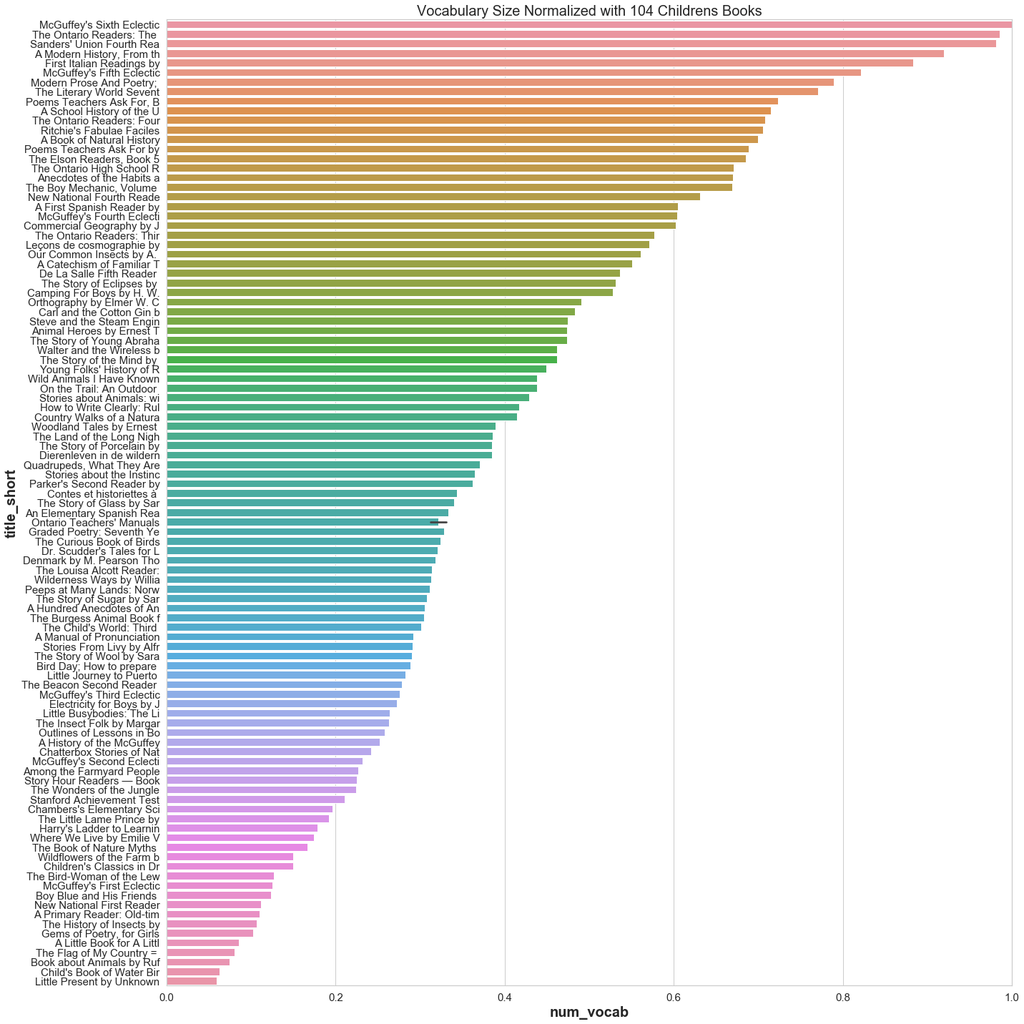

```python
## plot vocabulary normalized size as sorted in descending
plt.figure(figsize=(20,20))
sns.barplot('num_vocab','title_short', data=results_nrmlzd)
plt.xlim(0, 1)
plt.title('Vocabulary Size Normalized with 104 Childrens Books', fontsize = '20')
plt.xlabel('num_vocab', fontsize = 20, weight = 'bold')
plt.ylabel('title_short', fontsize = 20, weight = 'bold')

plt.savefig(plot_dir + 'normalized_vocab.png')
plt.tight_layout()
```

```python
## write table to output file for future reference
os.chdir(home_dir)
file_name = "vocab_normalized.csv"
results_nrmlzd.to_csv(file_name, header = True, index = None, sep=',', mode = 'a', float_format='%.4f')
```

#### 1.4 - Explain in a short paragraph

Back to top

For normalizing the score from 0 to 1, the vocabulary size normalization score for each text was calculated as the simple ratio of the vocabulary size of each text to the largest vocabulary size of any text. The score distributions for each text are shown the barplots in section 1.3. Most books categories have vocab_normalized scores between 0.2 and 0.8. "McGuffey’s Sixth Eclectic Reader" is the highest at 1, and "Little Present by Unknown" is the lowest at 0.06.

#### 2. Question 2

After consulting section 3.2 in chapter 1 of Bird-Klein, create a method for scoring the long-word vocabulary size of a text, and likewise normalize (and explain) the scoring as in step 1 above.

Back to top

In this section, create a method for scoring the long-word vocabulary size of a text, normalize the score from 0 to 1, barplot and save data to csv file, and briefly summarize the results.

#### 2.1 - Create a method for scoring the long-word vocabulary size of a text

Back to top

```python
## fine-grained selection of words (page 19: Bird-Klein w > 15)
def long_words(text_input) :
    text_unique = set(text_input)
    long_words = [w for w in text_unique if len(w) > 10] # use 10 here
    longest = sorted(long_words, key = len, reverse = True)[0]
    return longest
```

```python
## remove all non-alpha characters
def clean_text(start_text) :
    text = [re.sub('^((?![a-zA-Z ]).)*$', '', x) for x in start_text]
    text = [x.lower() for x in text]
    text = [x for x in text if x != '']
    return text

## sample regex breakdones
# .  for matching any single character
# ^  for matching the start of the string
# $  for matching the end of the string
# *  for matching zero or more cases of the previous mentioned regex before the  *  symbol in the pattern
# ?  for matching zero or one case of the previous mentioned regex before the  ?  symbol in the pattern
# \w  for matching alphanumeric characters also depicted as [a-zA-Z0-9_]
```

```python
## read in text with gutenberg license removed and assemble corpus for eva
readers = PlaintextCorpusReader(corpus_clean, files)

files = readers.fileids()
files[0:15]
```

```
['A Book of Natural History by David Starr Jordan.txt',
 'A Catechism of Familiar Things; by Anonymous.txt',
 'A First Spanish Reader by Alfred Remy and Erwin W. Roessler.txt',
 'A History of the McGuffey Readers by Henry Hobart Vail.txt',
 'A Hundred Anecdotes of Animals by Percy J. Billinghurst.txt',
 'A Little Book for A Little Cook by L. P. Hubbard.txt',
 'A Manual of Pronunciation by Otis Ashmore.txt',
 'A Modern History, From the Time of Luther to the Fall of Napoleon by John Lord.txt',
 'A Primary Reader: Old-time Stories, Fairy Tales and Myths Retold by Children.txt',
 'A School History of the United States by John Bach McMaster.txt',
 'Among the Farmyard People by Clara Dillingham Pierson.txt',
 'An Elementary Spanish Reader by Earl Stanley Harrison.txt',
 'Anecdotes of the Habits and Instinct of Animals by Mrs. R. Lee.txt',
 'Animal Heroes by Ernest Thompson Seton.txt',
 'Bird Day; How to prepare for it by Charles Almanzo Babcock.txt']
```

```python
## create table to accumulate summary data
Table_Q2 = pd.DataFrame(columns = ['text_name', 'long_mot', 'long_word_length'])
i_index = []
i_index = 0
```

```python
## loop through each text to assemble metrics
## print("Some basic statistics\n")

for fileid in readers.fileids():
    rtxt = clean_text(readers.words(fileid))
    le_mot_le_plus_long = long_words(rtxt)
    ## print("\n", i_index, "--", fileid, " : ", le_mot_le_plus_long, "\n")

    table_data = {'text_name': fileid, 'long_mot': le_mot_le_plus_long, 'long_word_length': len(le_mot_le_plus_long)}

    df_tbl = pd.DataFrame(table_data, columns = ['text_name','long_mot', 'long_word_length'], index = [i_index + 1])

    i_index += 1
    Table_Q2 = Table_Q2.append(df_tbl)
```

```python
## basic statistics table complete
Table_Q2 = Table_Q2.sort_values(Table_Q2.columns[2], ascending = False)

Table_Q2[:10]
```

|  | text_name | long_mot | long_word_length |
| --- | --- | --- | --- |
| 86 | The Ontario Readers: Fourth Book by Ontario. D... | osieontarioreadersfourth00miniuoft | 34 |
| 29 | Dierenleven in de wildernis by William J. Long... | gehoorzaamheidsinstinct | 23 |
| 62 | Sanders' Union Fourth Reader by Charles W. San... | _m_a_j_e_st_i_c_a_ll_y | 22 |
| 28 | Denmark by M. Pearson Thomson.txt | kristenbernikovstrade | 21 |
| 87 | The Ontario Readers: The High School Reader, 1... | contradistinguished | 19 |
| 37 | Leçons de cosmographie by Adrien Guilmin.txt | trigonométriquement | 19 |
| 1 | A Book of Natural History by David Starr Jorda... | disproportionately | 18 |
| 24 | Commercial Geography by Jacques W. Redway.txt | intercommunication | 18 |
| 81 | The Land of the Long Night by Paul B. Du Chail... | characteristically | 18 |
| 75 | The Curious Book of Birds by Abbie Farwell Bro... | congregationalist_ | 18 |

#### 2.2 - Normalize the score from 0 to 1

Back to top

```python
## normalize each column by max column value
results_nrmlzd = Table_Q2.copy()
results_nrmlzd = results_nrmlzd.sort_values(results_nrmlzd.columns[2], ascending = False)

df = results_nrmlzd.iloc[:, 2]
df_nrml = df / df.max()

df_labels = results_nrmlzd.iloc[:, 0]
df_words =  results_nrmlzd.iloc[:, 1]

results_nrmlzd = pd.concat([df_labels, df_words, df_nrml], axis = 1)

print('results_nrmlzd - ')

results_nrmlzd = results_nrmlzd.sort_values(results_nrmlzd.columns[2], ascending = False)
print('results_nrmlzd - sorted by col num_vocab')
results_nrmlzd[:10]
```

```
results_nrmlzd -
results_nrmlzd - sorted by col num_vocab
```

|  | text_name | long_mot | long_word_length |
| --- | --- | --- | --- |
| 86 | The Ontario Readers: Fourth Book by Ontario. D... | osieontarioreadersfourth00miniuoft | 1 |
| 29 | Dierenleven in de wildernis by William J. Long... | gehoorzaamheidsinstinct | 0.676471 |
| 62 | Sanders' Union Fourth Reader by Charles W. San... | _m_a_j_e_st_i_c_a_ll_y | 0.647059 |
| 28 | Denmark by M. Pearson Thomson.txt | kristenbernikovstrade | 0.617647 |
| 87 | The Ontario Readers: The High School Reader, 1... | contradistinguished | 0.558824 |
| 37 | Leçons de cosmographie by Adrien Guilmin.txt | trigonométriquement | 0.558824 |
| 60 | Quadrupeds, What They Are and Where Found: A B... | disproportionately | 0.529412 |
| 1 | A Book of Natural History by David Starr Jorda... | disproportionately | 0.529412 |
| 24 | Commercial Geography by Jacques W. Redway.txt | intercommunication | 0.529412 |
| 81 | The Land of the Long Night by Paul B. Du Chail... | characteristically | 0.529412 |

#### 2.3 - Barplot and save data to .csv file

Back to top

```python
## add some shorter title names to fit within plotting space
Table_Q2['title_short'] = [txt[:25] for txt in Table_Q2['text_name']]
Table_Q2['title_short'][:5]

results_nrmlzd['title_short'] = [txt[:25] for txt in results_nrmlzd['text_name']]
results_nrmlzd['title_short'][:5]

results_nrmlzd = results_nrmlzd.sort_values(results_nrmlzd.columns[2], ascending = False)
```

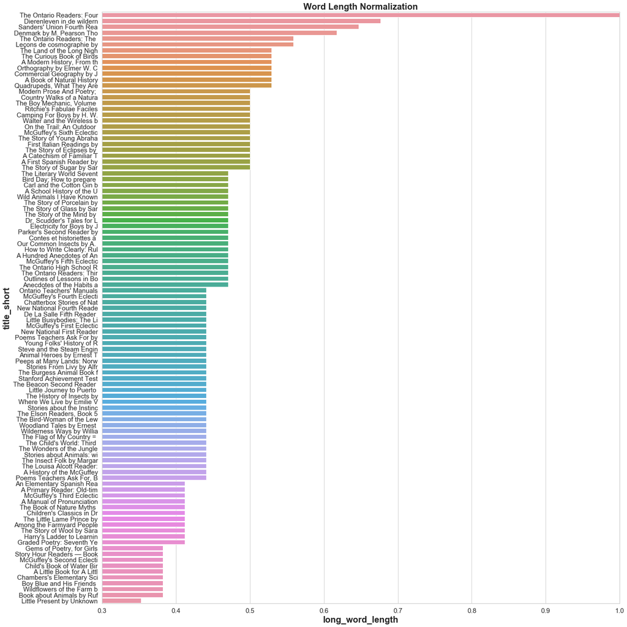

```python
## plot word length normalized and sorted in descending order
plt.figure(figsize=(20,20))
sns.barplot('long_word_length','title_short', data=results_nrmlzd)
plt.xlim(0.3, 1)
plt.title('Word Length Normalization', fontsize = '20', weight = 'bold')
plt.xlabel('long_word_length', fontsize = 20, weight = 'bold')
plt.ylabel('title_short', fontsize = 20, weight = 'bold')

plt.savefig(plot_dir + 'word_length_nNormalization.png')
plt.tight_layout()
```

```python
## write table to output file for future reference
os.chdir(home_dir)
file_name = "max_word_length_normalized.csv"
results_nrmlzd.to_csv(file_name, header = True, index = None, sep=',', mode = 'a', float_format='%.4f')
```

#### 2.4 - Explain in a short paragraph

Back to top

For normalizing the score from 0 to 1, the vocabulary length normalization score for each text was calculated as the simple ratio of the vocabulary length of each text to the maximum vocabulary length (34). The score distributions for each text are shown the barplots in section 2.3.

#### 3. Question 3

Now create a “text difficulty score” by combining the lexical diversity score from homework 1, and your normalized score of vocabulary size and long-word vocabulary size, in equal weighting. Explain what you see when this score is applied to same graded texts you used in homework 1.

Back to top

In this section, create a "text difficulty score" with scores from 3 methods ('vocab_nrml', 'lex_div_nrml' and "word_length_nrml"), barplot and save data to csv file, and briefly summarize the results.

#### 3.1 - Create a "text difficulty score" with scores from 3 methods

Back to top

```python
## some directory and file name definitions
files = ".*\.txt"
home_dir = "/Users/shanqinggu/Desktop/HW2"
corpus_root = "./text"
corpus_clean = "./text_cleaned/"
plot_dir = "./plots/"

os.chdir(home_dir)
```

```python
## read in saved .txt files (.csv) from normalizations
file_wordl = 'max_word_length_normalized.csv'
file_vocab = 'vocab_normalized.csv'

selected_texts = ["McGuffey's Second Eclectic Reader by William Holmes McGuffey.txt",
                  "McGuffey's Fourth Eclectic Reader by William Holmes McGuffey.txt",
                  "McGuffey's Sixth Eclectic Reader by William Holmes McGuffey.txt"]

df_wordl = pd.read_csv(file_wordl)
df_vocab = pd.read_csv(file_vocab)
```

```python
## condense to normalized metrics and selected texts

df_vocab_subset = df_vocab.loc[df_vocab['text_name'].isin(selected_texts)]
df_wordl_subset = df_wordl.loc[df_wordl['text_name'].isin(selected_texts)]

df_vocab_subset = df_vocab_subset[['text_name', 'title_short', 'num_vocab', 'lex_div']]
df_wordl_subset = df_wordl_subset[['text_name','long_word_length']]

df_vocab_subset = df_vocab_subset.sort_values(df_vocab_subset.columns[0])
df_wordl_subset = df_wordl_subset.sort_values(df_wordl_subset.columns[0])

df_vocab_subset = df_vocab_subset.reset_index(drop=True)
df_wordl_subset = df_wordl_subset.reset_index(drop=True)

df_wordl_subset = df_wordl_subset[['long_word_length']]

df_metrics = pd.concat([df_vocab_subset, df_wordl_subset], axis = 1)
df_metrics.columns = ['text_name', 'title_short', 'vocab_nrml', 'lex_div_nrml', 'word_length_nrml']
```

```python
## combine all 3 normalized metrics to total score (use average because of equal weight)
df_metrics['tds_scores'] = (df_metrics['vocab_nrml'] + df_metrics['lex_div_nrml'] + df_metrics['word_length_nrml'])/3

df_metrics = df_metrics.sort_values(df_metrics.columns[5], ascending = False)
df_metrics
```

|  | text_name | title_short | vocab_nrml | lex_div_nrml | word_length_nrml | tds_scores |
| --- | --- | --- | --- | --- | --- | --- |
| 2 | McGuffey's Sixth Eclectic Reader by William Ho... | McGuffey's Sixth Eclectic | 1.000000 | 0.3894 | 0.500000 | 0.629800 |
| 0 | McGuffey's Fourth Eclectic Reader by William H... | McGuffey's Fourth Eclecti | 0.604065 | 0.4618 | 0.441176 | 0.502347 |
| 1 | McGuffey's Second Eclectic Reader by William H... | McGuffey's Second Eclecti | 0.232017 | 0.5998 | 0.382353 | 0.404723 |

#### 3.2 - Barplots of text difficulty scores

Back to top

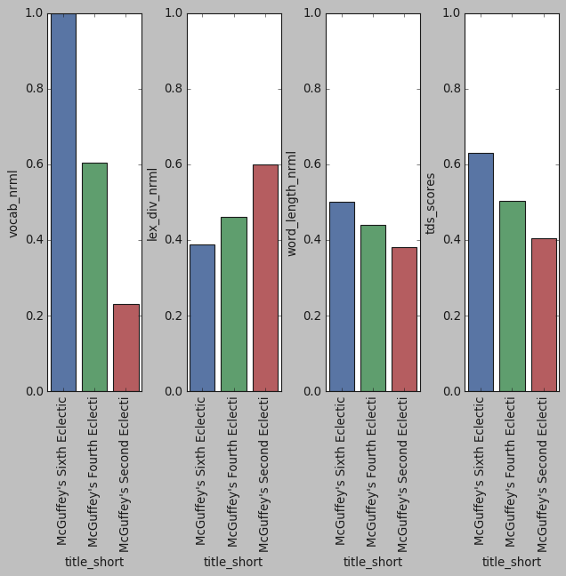

```python
# plot comparison of all (normalized) metrics - sorted in descending mlt_scores order

plt.style.use('classic')

fig, axs = plt.subplots(ncols=4)

for x, subplot in np.ndenumerate(axs):
    subplot.set_ylim(0,1)

fig.tight_layout()

_=plt.figure(figsize=(12, 6))

_=plt.setp(axs[0].xaxis.get_majorticklabels(), rotation = 90 )
_=plt.setp(axs[1].xaxis.get_majorticklabels(), rotation = 90 )
_=plt.setp(axs[2].xaxis.get_majorticklabels(), rotation = 90 )
_=plt.setp(axs[3].xaxis.get_majorticklabels(), rotation = 90 )

_=sns.barplot(x ='title_short', y = "vocab_nrml", data = df_metrics[['title_short', 'vocab_nrml']], ax = axs[0])
_=sns.barplot(x ='title_short', y = "lex_div_nrml", data = df_metrics[['title_short', 'lex_div_nrml']], ax = axs[1])
_=sns.barplot(x ='title_short', y = "word_length_nrml", data = df_metrics[['title_short', 'word_length_nrml']], ax = axs[2])
_=sns.barplot(x ='title_short', y = "tds_scores", data = df_metrics[['title_short', 'tds_scores']], ax = axs[3])

_=plt.show()
```

#### 3.3 Explain when this score is applied to same graded texts used in HW1

Back to top

The text difficulty score (TDS) used in this homework was calculated with the equal weight of normalized values of lexical diversity score, vocabulary size score, and vocabulary length score. In other words, we took the average of these three score to make TDS for applying to same graded texts used in homework 1.

As shown in the barplots, TDS score method is relatively more accurate to reflect the text difficulties for McGuffey readers after adjusting these three scoring methods with equal weights.

There are still rooms to improve TDS scoring method, such as to choose different weights, further clean the texts, consider different languages.

#### References

1. Steven Bird, Ewan Klein, Edward Loper. Natural language processing with Python. O’Reilly Media, Inc., 2009. Print.
2. Computing with Language: Texts and Words. http://www.nltk.org/book/ch01.html
3. Beautiful Soup Documentation. https://www.crummy.com/software/BeautifulSoup/bs4/doc/
4. Dr. Robert Slater and Ben Brock's class notes on HW2.

-- The End of Homework 02 --